# Predict Analysis - Human Activity Recognition

Igor Alcantara

February 23, 2016

# Author

This prediction and document were created by Igor Alcantara. You can contact him at igor@igoralcantara.com.br.

# Background

Using devices such as Jawbone Up, Nike FuelBand, and Fitbit it is now possible to collect a large amount of data about personal activity relatively inexpensively. These type of devices are part of the quantified self movement – a group of enthusiasts who take measurements about themselves regularly to improve their health, to find patterns in their behavior, or because they are tech geeks.

One thing that people regularly do is quantify how much of a particular activity they do, but they rarely quantify how well they do it. In this project, the goal is to use data from accelerometers on the belt, forearm, arm, and dumbell of 6 participants. They were asked to perform barbell lifts correctly and incorrectly in 5 different ways.

More information is available from the website here: http://groupware.les.inf.puc-rio.br/har.

# Data

The training data for this project are available here:

https://d396qusza40orc.cloudfront.net/predmachlearn/pml-training.csv

The test data are available here:

https://d396qusza40orc.cloudfront.net/predmachlearn/pml-testing.csv

The data for this project come from this source: http://groupware.les.inf.puc-rio.br/har. If you use the document you create for this class for any purpose please cite them as they have been very generous in allowing their data to be used for this kind of assignment.

# Importing the libraries needed for this assignment

This assignment uses the Caret package in R for most of the tasks preparing the data, testing the models and making predictions. RPart and Rattle are used to create the model using Decison Tree algorithm and plot it.

```r
library(caret)
```

```r
library(rpart)
library(rpart.plot)
library(rattle)
```

Let’s also import some libraries to plot the train data before any model is built.

```r
library(ggplot2)
library(ggthemes)
library(grid)
library(gridExtra)
```

# Loading and understading the data

First task is to load the two datasets available: Train and Test.

```r
trainData <- read.csv("pml-training.csv")
testData <- read.csv("pml-testing.csv")
```

Let’s see how many rows and columns there are in the Train dataset.

```r
dim(trainData)
```

```
## [1] 19622   160
```

With the objective to see how somme of the variables are distributed, I will build 4 density plots focusing on the variables Gyro Belt, Pitch Belt, Magnet Belt and Dumbell Movement. They are related to the different movement and activity metrics measure in 3 axis. Each axis is represented by o a different color. Gyro Belt and Magnet Belts are reported in x, y and z axis. Pitch Belt and Dumbell are reported in types of movement: yaw, pitch and roll.

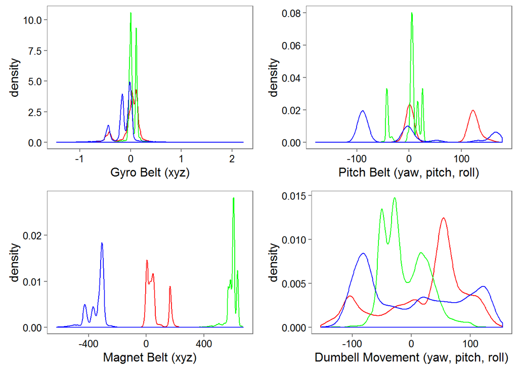

```r
plot_A <- ggplot() + geom_density(aes(x=gyros_belt_x), colour="red", data=trainData) +
                     geom_density(aes(x=gyros_belt_y), colour="green", data=trainData) +
                     geom_density(aes(x=gyros_belt_z), colour="blue", data=trainData) +
          theme_few() + xlab("Gyro Belt (xyz)")

plot_B <- ggplot() + geom_density(aes(x=roll_belt), colour="red", data=trainData) +
                     geom_density(aes(x=pitch_belt), colour="green", data=trainData) +
                     geom_density(aes(x=yaw_belt), colour="blue", data=trainData) +
          theme_few() + xlab("Pitch Belt (yaw, pitch, roll)")

plot_C <- ggplot() + geom_density(aes(x=magnet_belt_x), colour="red", data=trainData) +
                     geom_density(aes(x=magnet_belt_y), colour="green", data=trainData) +
                     geom_density(aes(x=magnet_belt_z), colour="blue", data=trainData) +
          theme_few() + xlab("Magnet Belt (xyz)")

plot_D <- ggplot() + geom_density(aes(x=roll_dumbbell), colour="red", data=trainData) +
                     geom_density(aes(x=pitch_dumbbell), colour="green", data=trainData) +
                     geom_density(aes(x=yaw_dumbbell), colour="blue", data=trainData) +
          theme_few() + xlab("Dumbell Movement (yaw, pitch, roll)")

gridPlots <- arrangeGrob(plot_A, plot_B, plot_C, plot_D, nrow = 2, ncol = 2)
grid.draw(gridPlots)
```

# Getting the Data Ready

In order to calculate the “Out of Sample Error”, I will split the training dataset into two subsets: training and validation. Training Dataset contains 70% of the original training dataset. The Seed is being set for reproducibility reasons.

```r
set.seed(5777) #it turns out that the Seed is my birthdate (May-07-1977) :)
isInTrain <- createDataPartition(y=trainData$classe, p=0.7, list=F)
trainData1 <- trainData[isInTrain, ]
trainData2 <- trainData[-isInTrain, ]
```

A large number of predictors are usually a problem when making predictions. For that reason, the next task in preparing the data is to eliminate predictors with nearly zero variance. Those include variables where most of the values are NA and variables with small variability.

Notice that I decide which ones to remove by analyzing trainData1, and perform the identical removals on trainData2:

```r
# Step 01 - remove predictors with nearly zero variance
nzv <- nearZeroVar(trainData1)
trainData1 <- trainData1[, -nzv]
trainData2 <- trainData2[, -nzv]

# Step 02 - remove predictors that are almost all NA
majorityNAs <- sapply(trainData1, function(x) mean(is.na(x))) > 0.95
trainData1 <- trainData1[, majorityNAs==F]
trainData2 <- trainData2[, majorityNAs==F]

# Step 03 - remove variables that don't make intuitive sense for prediction (X, user_name, raw_timestamp_part_1, raw_timestamp_part_2, cvtd_timestamp), which happen to be the first five variables
trainData1 <- trainData1[, -(1:5)]
trainData2 <- trainData2[, -(1:5)]
```

Remember we have originaly 160 variables in the dataset. Let’s see now after this cleanup how many we have. Notice many variables were removed and now we have a much smaller and meaninful set of predictors.

```r
dim(trainData1)
```

```
## [1] 13737    54
```

# Create the Prediction Models

I will now create 4 prediction models and then select the one that gives the most accurate prediction. For each one of the models I will create a 4-fold cross validation to select the best tuning parameters.

## Model 01 - Linear Discriminant Analysis

```r
# instruct train to use 2-fold CV to select optimal tuning parameters
fitControl <- trainControl(method="cv", number=4, verboseIter=FALSE)

# fit model on trainData1
fit1 <- train(classe ~ ., data=trainData1, method="lda", trControl=fitControl, verbose=FALSE)
fit1$finalModel
```

```
## Call:
## lda(x, grouping = y, verbose = FALSE)
##
## Prior probabilities of groups:
##         A         B         C         D         E
## 0.2843416 0.1934920 0.1744195 0.1639368 0.1838101
##
## Group means:
##   num_window roll_belt pitch_belt   yaw_belt total_accel_belt gyros_belt_x
## A   388.9895  59.41922  0.8829749 -13.259222         10.70558 -0.005668203
## B   505.0519  64.50236  0.1028029 -14.405237         11.06960 -0.004770504
## C   484.8602  64.54029 -0.7631219  -8.462129         11.14274 -0.015208681
## D   434.4107  62.10092  1.7507771 -16.584489         11.34325 -0.014107460
## E   374.7850  74.79946  0.5248634  -5.161568         12.73505  0.007564356
##   gyros_belt_y gyros_belt_z accel_belt_x accel_belt_y accel_belt_z
## A   0.04035330   -0.1220917    -6.867896     29.19329    -62.94726
## B   0.04268999   -0.1330436    -5.153875     31.69940    -72.48420
## C   0.03939900   -0.1347204    -4.343072     31.10434    -70.73038
## D   0.03857016   -0.1330284    -7.925844     30.94760    -71.63943
## E   0.03695050   -0.1358059    -4.540594     29.07683    -92.27604
##   magnet_belt_x magnet_belt_y magnet_belt_z   roll_arm  pitch_arm
## A      56.55223      602.2322     -337.8766 -0.4324219   2.692220
## B      48.92287      599.6832     -336.3627 31.4538074  -6.224187
## C      56.36269      599.7826     -337.6256 25.3425710  -1.480146
## D      49.13188      592.9085     -342.3193 22.1408925 -10.261576
## E      63.25703      567.8570     -378.6523 20.3636634 -12.535925
##      yaw_arm total_accel_arm gyros_arm_x gyros_arm_y gyros_arm_z
## A -11.793528        27.47517  0.05301075  -0.2318254   0.2691014
## B   7.096373        26.59481  0.01037246  -0.2772009   0.2638450
## C   4.148535        24.37604  0.15002087  -0.2802755   0.2781386
## D   6.038011        23.27265  0.04535968  -0.2574245   0.2768783
## E  -1.277521        24.43525  0.05630891  -0.2838931   0.2786653
##   accel_arm_x accel_arm_y accel_arm_z magnet_arm_x magnet_arm_y
## A  -131.88991    46.68356   -75.69918    -20.23118    235.89555
## B   -43.65764    26.89202   -95.07035    235.34424    130.61324
## C   -79.23289    41.09558   -54.83013    149.33264    191.84474
## D    12.27442    24.61190   -45.34325    390.56616    100.86856
## E   -19.98931    16.80554   -74.68396    317.23762     86.88515
##   magnet_arm_z roll_dumbbell pitch_dumbbell yaw_dumbbell
## A     409.8825      20.25836     -18.915811     2.934455
```

[output cut: 139 more lines]

```
## yaw_forearm           1.013931e-03
## total_accel_forearm   2.931814e-03
## gyros_forearm_x       1.299129e-01
## gyros_forearm_y       5.084525e-03
## gyros_forearm_z      -3.651470e-02
## accel_forearm_x       4.132546e-03
## accel_forearm_y      -1.910202e-03
## accel_forearm_z      -4.512588e-03
## magnet_forearm_x     -1.241711e-03
## magnet_forearm_y      2.577741e-04
## magnet_forearm_z      1.116207e-03
##
## Proportion of trace:
##    LD1    LD2    LD3    LD4
## 0.4761 0.2397 0.1705 0.1137
```

## Model 02 - Decision Tree

For this model we will see the results using the Fancy Plot.

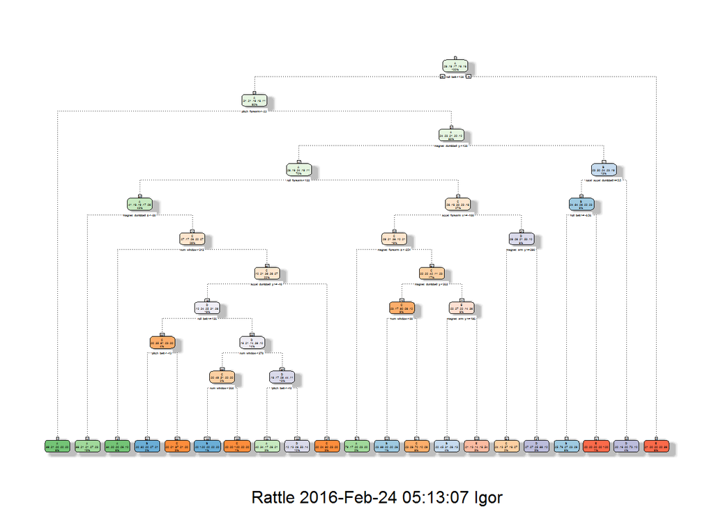

```r
fit2 <- rpart(classe ~ ., data=trainData1, method="class")
fancyRpartPlot(fit2)
```

## Model 03 - Random Forest

```r
# fit model on trainData1
fit3 <- train(classe ~ ., data=trainData1, method="rf", trControl=fitControl, verbose=FALSE)
fit3$finalModel
```

```
##
## Call:
##  randomForest(x = x, y = y, mtry = param$mtry, verbose = FALSE)
##                Type of random forest: classification
##                      Number of trees: 500
## No. of variables tried at each split: 27
##
##         OOB estimate of  error rate: 0.25%
## Confusion matrix:
##      A    B    C    D    E class.error
## A 3906    0    0    0    0 0.000000000
## B    7 2647    3    1    0 0.004138450
## C    0    5 2391    0    0 0.002086811
## D    0    0   12 2239    1 0.005772647
## E    0    1    0    4 2520 0.001980198
```

## Model 04 - Gradient Boosted Model

```r
# fit model on trainData1
fit4 <- train(classe ~ ., data=trainData1, method="gbm", trControl=fitControl, verbose=FALSE)
fit4$finalModel
```

```
## A gradient boosted model with multinomial loss function.
## 150 iterations were performed.
## There were 53 predictors of which 41 had non-zero influence.
```

# Chosing the best model

Now it is time to predict using each model and check for the accuracy of each prediction in a Confusion Matrix in order to select the best model. Since trainData1 was used to train the data, we will use trainData2 to predict. By doing that we want to calculate the Out of Sample Error and to avoid overfitting the model.

```r
predict1 <- predict(fit1, newdata=trainData2)
confusionMatrix(trainData2$classe, predict1)
```

```
## Confusion Matrix and Statistics
##
##           Reference
## Prediction    A    B    C    D    E
##          A 1395   55   93  126    5
##          B  143  762  139   57   38
##          C  108   93  680  118   27
##          D   64   33  119  717   31
##          E   43  160  102  106  671
##
## Overall Statistics
##
##                Accuracy : 0.7179
##                  95% CI : (0.7062, 0.7294)
##     No Information Rate : 0.2979
##     P-Value [Acc > NIR] : < 2.2e-16
##
##                   Kappa : 0.643
##  Mcnemar's Test P-Value : < 2.2e-16
##
## Statistics by Class:
##
##                      Class: A Class: B Class: C Class: D Class: E
## Sensitivity            0.7958   0.6908   0.6002   0.6379   0.8692
## Specificity            0.9325   0.9212   0.9272   0.9481   0.9196
## Pos Pred Value         0.8333   0.6690   0.6628   0.7438   0.6201
## Neg Pred Value         0.9150   0.9282   0.9068   0.9173   0.9790
## Prevalence             0.2979   0.1874   0.1925   0.1910   0.1312
## Detection Rate         0.2370   0.1295   0.1155   0.1218   0.1140
## Detection Prevalence   0.2845   0.1935   0.1743   0.1638   0.1839
## Balanced Accuracy      0.8641   0.8060   0.7637   0.7930   0.8944
```

```r
predict2 <- predict(fit2, newdata=trainData2, type="class")
confusionMatrix(trainData2$classe, predict2)
```

```
## Confusion Matrix and Statistics
##
##           Reference
## Prediction    A    B    C    D    E
##          A 1513   42   18   94    7
##          B  261  640   76  119   43
##          C   53   97  755   82   39
##          D  115   38   84  657   70
##          E   73   83   47  157  722
##
## Overall Statistics
##
##                Accuracy : 0.7285
##                  95% CI : (0.7169, 0.7398)
##     No Information Rate : 0.3424
##     P-Value [Acc > NIR] : < 2.2e-16
##
##                   Kappa : 0.6543
##  Mcnemar's Test P-Value : < 2.2e-16
##
## Statistics by Class:
##
##                      Class: A Class: B Class: C Class: D Class: E
## Sensitivity            0.7509   0.7111   0.7704   0.5924   0.8195
## Specificity            0.9584   0.8999   0.9448   0.9357   0.9281
## Pos Pred Value         0.9038   0.5619   0.7359   0.6815   0.6673
## Neg Pred Value         0.8808   0.9452   0.9537   0.9081   0.9669
## Prevalence             0.3424   0.1529   0.1665   0.1884   0.1497
## Detection Rate         0.2571   0.1088   0.1283   0.1116   0.1227
## Detection Prevalence   0.2845   0.1935   0.1743   0.1638   0.1839
## Balanced Accuracy      0.8546   0.8055   0.8576   0.7641   0.8738
```

```r
predict3 <- predict(fit3, newdata=trainData2)
confusionMatrix(trainData2$classe, predict3)
```

```
## Confusion Matrix and Statistics
##
##           Reference
## Prediction    A    B    C    D    E
##          A 1672    1    0    0    1
##          B    5 1133    1    0    0
##          C    0    1 1025    0    0
##          D    0    0    5  959    0
##          E    0    0    0    4 1078
##
## Overall Statistics
##
##                Accuracy : 0.9969
##                  95% CI : (0.9952, 0.9982)
##     No Information Rate : 0.285
##     P-Value [Acc > NIR] : < 2.2e-16
##
##                   Kappa : 0.9961
##  Mcnemar's Test P-Value : NA
##
## Statistics by Class:
##
##                      Class: A Class: B Class: C Class: D Class: E
## Sensitivity            0.9970   0.9982   0.9942   0.9958   0.9991
## Specificity            0.9995   0.9987   0.9998   0.9990   0.9992
## Pos Pred Value         0.9988   0.9947   0.9990   0.9948   0.9963
## Neg Pred Value         0.9988   0.9996   0.9988   0.9992   0.9998
## Prevalence             0.2850   0.1929   0.1752   0.1636   0.1833
## Detection Rate         0.2841   0.1925   0.1742   0.1630   0.1832
## Detection Prevalence   0.2845   0.1935   0.1743   0.1638   0.1839
## Balanced Accuracy      0.9983   0.9985   0.9970   0.9974   0.9991
```

```r
predict4 <- predict(fit4, newdata=trainData2)
confusionMatrix(trainData2$classe, predict4)
```

```
## Confusion Matrix and Statistics
##
##           Reference
## Prediction    A    B    C    D    E
##          A 1670    3    0    1    0
##          B   18 1106   14    0    1
##          C    0    8 1015    2    1
##          D    0    8   13  940    3
##          E    0    5    2   10 1065
##
## Overall Statistics
##
##                Accuracy : 0.9849
##                  95% CI : (0.9814, 0.9878)
##     No Information Rate : 0.2868
##     P-Value [Acc > NIR] : < 2.2e-16
##
##                   Kappa : 0.9809
##  Mcnemar's Test P-Value : NA
##
## Statistics by Class:
##
##                      Class: A Class: B Class: C Class: D Class: E
## Sensitivity            0.9893   0.9788   0.9722   0.9864   0.9953
## Specificity            0.9990   0.9931   0.9977   0.9951   0.9965
## Pos Pred Value         0.9976   0.9710   0.9893   0.9751   0.9843
## Neg Pred Value         0.9957   0.9949   0.9940   0.9974   0.9990
## Prevalence             0.2868   0.1920   0.1774   0.1619   0.1818
## Detection Rate         0.2838   0.1879   0.1725   0.1597   0.1810
## Detection Prevalence   0.2845   0.1935   0.1743   0.1638   0.1839
## Balanced Accuracy      0.9942   0.9859   0.9850   0.9907   0.9959
```

These are the results for Accuracy and Out of Sample Errors for each one of the models:

- Linear Discriminant Analysis – Accuracy: 71% – Out of Sample Error: 29%
- Decision Tree – Accuracy: 72% – Out of Sample Error: 28%
- Random Forest – Accuracy: 99% – Out of Sample Error: 1%
- Generalized Boosted Model – Accuracy: 98% – Out of Sample Error: 2%

# Submit the selected method to another round of training

Now that the model is selected, we will retrain it using the complete training dataset. For that, we will use the same code it was used to prepare the data and train the models.

```r
# Step 01 - remove predictors with nearly zero variance
nzv <- nearZeroVar(trainData)
trainData <- trainData[, -nzv]
testData <- testData[, -nzv]

# Step 02 - remove predictors that are almost all NA
majorityNAs <- sapply(trainData, function(x) mean(is.na(x))) > 0.95
trainData <- trainData[, majorityNAs==FALSE]
testData <- testData[, majorityNAs==FALSE]

# Step 03 - remove variables that don't make intuitive sense for prediction (X, user_name, raw_timestamp_part_1, raw_timestamp_part_2, cvtd_timestamp), which happen to be the first five variables
trainData <- trainData[, -(1:5)]
testData <- testData[, -(1:5)]

# Step 04 - re-build model using full training set (trainData)
fitControl <- trainControl(method="cv", number=5, verboseIter=FALSE, allowParallel = TRUE)
fitModel <- train(classe ~ ., data=trainData, method="rf", trControl=fitControl)
```

# Saving predictions in a file for assignment submission

At a last step, the predictions will be saved in a file to be submitted in the quiz data.

```r
# predict on test set
predictions <- predict(fitModel, newdata=testData)

# convert predictions to character vector
predictions <- as.character(predictions)

#Loop the predictions and store the values in a text object
nPred <- length(predictions)
predictionTextFile <- ''
for(i in 1:nPred) {
  predictionTextFile <- paste0(predictionTextFile, "Problem ", i, ": ", predictions[i], "\n")
}

write.table(predictionTextFile, file="predictions.txt", quote=FALSE, row.names=FALSE, col.names=FALSE)
```

# References

- [Human Activity Recognition] (http://groupware.les.inf.puc-rio.br/har)
- [Linear Discriminant Analysis] (https://en.wikipedia.org/wiki/Linear_discriminant_analysis)
- [Decision Tree](https://en.wikipedia.org/wiki/Decision_tree)
- [Random Forest](https://en.wikipedia.org/wiki/Random_forest)
- [Gradient Boosted Model](http://www.ncbi.nlm.nih.gov/pmc/articles/PMC3885826/)
- [Author’s Web Site](http://igoralcantara.com.br)